# IML_Week_4_Assignment_Learner_template

## Objective

This homework sheet will help reviewing the basic concepts associated with classification models. Please review the lectures, suggested readings, and additional resources before getting started on the HW.

**Some questions in this assignment will require you to conduct independent research beyond the material covered in the recorded content.**

**Questions**

This homework is divided into two main parts. First, a conceptual component will review the basic concepts related to classification models. The second part of the homework is mostly intended to be a brief introduction to fitting and analyzing classifiers in `Python`. Several of these questions are modified from James et al. (2021).

Marks Distribution

| Question | Marks |
| --- | --- |
| 1a | 0.25 |
| 1b | 0.25 |
| 1c | 0.25 |
| 1d | 0.25 |
| 2a | 0.50 |
| 2b | 0.50 |
| 3 | 1 |
| 4a | 1 |
| 4b | 1 |
| 4c | 0.5 |
| 4d | 1 |
| 4e | 1 |
| 4f | 1 |
| 4g | 0.25 |
| 4h | 0.25 |
| 5a | 1 |
| 5b | 1 |
| 5c | 1 |
| 5d | 1 |
| 5e | 1 |
| 5f | 1 |

## Conceptual Questions

### Q1. Let’s examine the differences between LDA and QDA.

#### a) If the Bayes decision boundary is linear, do we expect LDA or QDA to perform better on the training set? What about in the test set?

We would expect QDA to perform better on the training set because its increased flexiblity will result in a closer fit. If the Bayes decision boundary is linear, we expect LDA to perform better than QDA on the test set, as QDA could be subject to overfitting.

#### b) If the Bayes decision boundary is non-linear, do we expect LDA or QDA to perform better on the training set? On the test set?

If the Bayes decision bounary is non-linear, we expect QDA to perform better on both the training and test sets.

#### c)In general, as the sample size n increases, do we expect the test prediction accuracy of QDA relative to LDA to improve, decline, or be unchanged? Why?

We expect the test prediction accuracy of QDA relative to LDA to improve as n gets bigger. In general, as the the sample size increases, a more flexibile method will yield a better fit as the variance is offset by the larger sample size.

#### d)True or False:

Even if the Bayes decision boundary for a given problem is linear, we will probably achieve a superior test error rate using QDA rather than LDA because QDA is flexible enough to model a linear decision boundary.

False. With fewer sample points, the variance from using a more flexible method, such as QDA, would likely result in overfitting, yielding a higher test error rate than LDA.

### Q2) In relation to the odds and the Default dataset

#### a) On average, what fraction of people with an odds of `0.37` of defaulting on their credit card payment will in fact default?

```python
# BEGIN SOLUTION
odds_of_event = 0.37
probability_of_event = odds_of_event/(1+odds_of_event)
print(probability_of_event)
# END SOLUTION
```

```
0.27007299270072993
```

#### b) Suppose that an individual has a `16%` chance of defaulting on their credit card payment. What are the odds that they will default?

```python
# BEGIN SOLUTION
probability_of_event = 0.16
odds = probability_of_event /(1-probability_of_event)
print(odds)
# END SOLUTION
```

```
0.1904761904761905
```

Odds of default≈0.1905

#### Q3. Suppose that we take a data set, divide it into equally sized training and test sets, and then try out two different classification procedures. First, we use logistic regression and get an error rate of `20%` on the training data and `30%` on the test data. Next we use 1-nearest neighbors (i.e. `K=1`) and get an average error rate (averaged over both test and training data sets) of `18%`. Based on these results, which method should we prefer to use for classification of new observations? Why?

1-nearest neighbor (KNN) with K=1 is preferred for classifying new observations.:

#### Average Error Rate:

The average error rate for KNN (18%) is lower than the average error rate for logistic regression (25%, calculated as the mean of 20% and 30%). This indicates that KNN makes fewer mistakes on both the training and test data sets compared to logistic regression. However, it's important to consider some additional factors before making a final decision:

#### Complexity of the decision boundary:

If the data has a complex, non-linear decision boundary, KNN might be better suited to capture those intricacies. Logistic regression excels at linear relationships and might underperform if the data is not linearly separable. Interpretability: Logistic regression provides a mathematical formula that can be analyzed to understand the relationship between features and the target variable. KNN is a non-parametric method and doesn't offer the same level of interpretability.

Based on these results, we should prefer the 1-Nearest Neighbors method for classification of new observations. It shows better performance in terms of error rates and appears to generalize better to unseen data compared to logistic regression.

## Applied

#### 4) This question should be answered using the `Weekly` data set, which is part of the `ISLR2` package. This data is similar in nature to the `Smarket` data examined in the book (Ch4, lab). First, load the dataset:

https://book.huihoo.com/introduction-to-statistical-learning/data.html

Link for getting rdataset into python: https://www.statsmodels.org/dev/datasets/statsmodels.datasets.get_rdataset.html

By using the below command you can get the ISLR dataset `sm.datasets.get_rdataset('Weekly', 'ISLR').data`

#### a) Produce some numerical and graphical summaries of the `Weekly` data. Can you identify any patterns? Hint: examine the **correlation** between predictors.

**Importing Libraries:**

```python
import statsmodels.api as sm
import pandas as pd
import seaborn as sns
import matplotlib.pyplot as plt
from sklearn.preprocessing import StandardScaler
```

**Loading dataset:**

```python
#READ Weekly DATASET USING THE CODE GIVEN IN QUESTION 4
df = sm.datasets.get_rdataset('Weekly', 'ISLR').data
df.head()
```

|  | Year | Lag1 | Lag2 | Lag3 | Lag4 | Lag5 | Volume | Today | Direction |
| --- | --- | --- | --- | --- | --- | --- | --- | --- | --- |
| 0 | 1990 | 0.816 | 1.572 | -3.936 | -0.229 | -3.484 | 0.154976 | -0.270 | Down |
| 1 | 1990 | -0.270 | 0.816 | 1.572 | -3.936 | -0.229 | 0.148574 | -2.576 | Down |
| 2 | 1990 | -2.576 | -0.270 | 0.816 | 1.572 | -3.936 | 0.159837 | 3.514 | Up |
| 3 | 1990 | 3.514 | -2.576 | -0.270 | 0.816 | 1.572 | 0.161630 | 0.712 | Up |
| 4 | 1990 | 0.712 | 3.514 | -2.576 | -0.270 | 0.816 | 0.153728 | 1.178 | Up |

```python
#PERFORM PRE PROCESSING OF DATA IF REQUIRED ( OBSERVE THE DATASET AND ITS VALUES CAREFULLY)

print("Missing Values:\n", df.isnull().sum())
df['Direction'] = df['Direction'].map({'Up': 1, 'Down': 0})
scaler = StandardScaler()
df[['Volume', 'Today']] = scaler.fit_transform(df[['Volume', 'Today']])
df.head()
```

```
Missing Values:
 Year         0
Lag1         0
Lag2         0
Lag3         0
Lag4         0
Lag5         0
Volume       0
Today        0
Direction    0
dtype: int64
```

|  | Year | Lag1 | Lag2 | Lag3 | Lag4 | Lag5 | Volume | Today | Direction |
| --- | --- | --- | --- | --- | --- | --- | --- | --- | --- |
| 0 | 1990 | 0.816 | 1.572 | -3.936 | -0.229 | -3.484 | -0.842087 | -0.178237 | 0 |
| 1 | 1990 | -0.270 | 0.816 | 1.572 | -3.936 | -0.229 | -0.845884 | -1.157079 | 0 |
| 2 | 1990 | -2.576 | -0.270 | 0.816 | 1.572 | -3.936 | -0.839203 | 1.427981 | 1 |
| 3 | 1990 | 3.514 | -2.576 | -0.270 | 0.816 | 1.572 | -0.838140 | 0.238598 | 1 |
| 4 | 1990 | 0.712 | 3.514 | -2.576 | -0.270 | 0.816 | -0.842827 | 0.436404 | 1 |

```python
# BEGIN SOLUTION
print("\nSummary Statistics after Pre-processing:\n", df.describe())
# END SOLUTION
```

```
Summary Statistics after Pre-processing:
               Year         Lag1         Lag2         Lag3         Lag4  \
count  1089.000000  1089.000000  1089.000000  1089.000000  1089.000000
mean   2000.048669     0.150585     0.151079     0.147205     0.145818
std       6.033182     2.357013     2.357254     2.360502     2.360279
min    1990.000000   -18.195000   -18.195000   -18.195000   -18.195000
25%    1995.000000    -1.154000    -1.154000    -1.158000    -1.158000
50%    2000.000000     0.241000     0.241000     0.241000     0.238000
75%    2005.000000     1.405000     1.409000     1.409000     1.409000
max    2010.000000    12.026000    12.026000    12.026000    12.026000

              Lag5        Volume         Today    Direction
count  1089.000000  1.089000e+03  1.089000e+03  1089.000000
mean      0.139893  5.219781e-17  6.524727e-18     0.555556
std       2.361285  1.000459e+00  1.000459e+00     0.497132
min     -18.195000 -8.821320e-01 -7.786972e+00     0.000000
25%      -1.166000 -7.370685e-01 -5.534740e-01     0.000000
50%       0.234000 -3.392553e-01  3.867021e-02     1.000000
75%       1.405000  2.841928e-01  5.327604e-01     1.000000
max      12.026000  4.599188e+00  5.041122e+00     1.000000
```

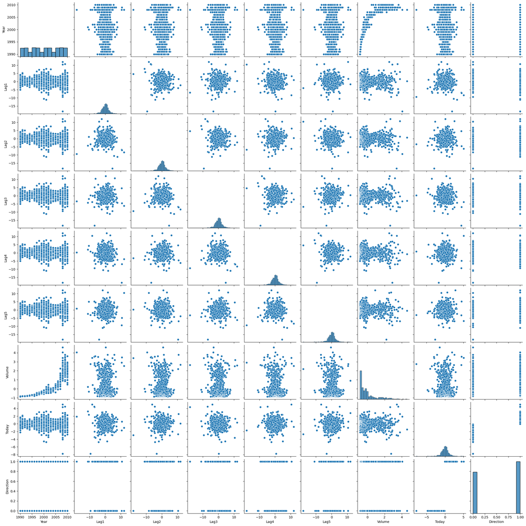

```python
# BEGIN SOLUTION
sns.pairplot(df)
plt.show()
# END SOLUTION
```

```python
# BEGIN SOLUTION
correlation_matrix = df.corr()
print("Correlation Matrix:\n", correlation_matrix)
# END SOLUTION
```

```
Correlation Matrix:
                Year      Lag1      Lag2      Lag3      Lag4      Lag5  \
Year       1.000000 -0.032289 -0.033390 -0.030006 -0.031128 -0.030519
Lag1      -0.032289  1.000000 -0.074853  0.058636 -0.071274 -0.008183
Lag2      -0.033390 -0.074853  1.000000 -0.075721  0.058382 -0.072499
Lag3      -0.030006  0.058636 -0.075721  1.000000 -0.075396  0.060657
Lag4      -0.031128 -0.071274  0.058382 -0.075396  1.000000 -0.075675
Lag5      -0.030519 -0.008183 -0.072499  0.060657 -0.075675  1.000000
Volume     0.841942 -0.064951 -0.085513 -0.069288 -0.061075 -0.058517
Today     -0.032460 -0.075032  0.059167 -0.071244 -0.007826  0.011013
Direction -0.022200 -0.050004  0.072696 -0.022913 -0.020549 -0.018168

             Volume     Today  Direction
Year       0.841942 -0.032460  -0.022200
Lag1      -0.064951 -0.075032  -0.050004
Lag2      -0.085513  0.059167   0.072696
Lag3      -0.069288 -0.071244  -0.022913
Lag4      -0.061075 -0.007826  -0.020549
Lag5      -0.058517  0.011013  -0.018168
Volume     1.000000 -0.033078  -0.017995
Today     -0.033078  1.000000   0.720025
Direction -0.017995  0.720025   1.000000
```

You can refer to the `seaborn` library documentation to attempt this problem: https://seaborn.pydata.org/

#### b) Use the full data set to perform a logistic regression with Direction as the response and the five `lag` variables plus `Volume` as predictors. Use the summary function to print the results. Do any of the predictors appear to be statistically significant? If so, which ones? Use the statsmodels to construct the classifier.

Link: https://www.statsmodels.org/

```python
#BEGIN SOLUTION
import statsmodels.api as sm

def perform_logistic_regression(data, predictors, response):
    logit_model = sm.Logit(df[response], sm.add_constant(df[predictors]))  # Add constant term
    result = logit_model.fit()
    return result

# END SOLUTION
```

```python
# BEGIN SOLUTION
predictors = ['Lag1', 'Lag2', 'Lag3', 'Lag4', 'Lag5', 'Volume']
response = 'Direction'
result = perform_logistic_regression(df, predictors, response)
print(result.summary())
# END SOLUTION
```

```
Optimization terminated successfully.
         Current function value: 0.682441
         Iterations 4
                           Logit Regression Results
==============================================================================
Dep. Variable:              Direction   No. Observations:                 1089
Model:                          Logit   Df Residuals:                     1082
Method:                           MLE   Df Model:                            6
Date:                Tue, 16 Apr 2024   Pseudo R-squ.:                0.006580
Time:                        17:40:56   Log-Likelihood:                -743.18
converged:                       True   LL-Null:                       -748.10
Covariance Type:            nonrobust   LLR p-value:                    0.1313
==============================================================================
                 coef    std err          z      P>|z|      [0.025      0.975]
------------------------------------------------------------------------------
const          0.2311      0.062      3.723      0.000       0.109       0.353
Lag1          -0.0413      0.026     -1.563      0.118      -0.093       0.010
Lag2           0.0584      0.027      2.175      0.030       0.006       0.111
Lag3          -0.0161      0.027     -0.602      0.547      -0.068       0.036
Lag4          -0.0278      0.026     -1.050      0.294      -0.080       0.024
Lag5          -0.0145      0.026     -0.549      0.583      -0.066       0.037
Volume        -0.0383      0.062     -0.616      0.538      -0.160       0.084
==============================================================================
```

Based on the logistic regression results, some predictors appear to be statistically significant. Among the predictors:

'Lag2' has a statistically significant coefficient with a p-value of 0.030. 'const' (intercept) also has a statistically significant coefficient with a p-value less than 0.05. Therefore, 'Lag2' and the intercept ('const') are the predictors that appear to be statistically significant in predicting the direction of the market.

#### C) Compute the confusion matrix and overall fraction of correct predictions. Explain what the confusion matrix is telling you about the types of mistakes made by logistic regression.

```python
# BEGIN SOLUTION
# Predict the probabilities of each class
predicted_probabilities = result.predict()

# Convert probabilities to binary predictions (0 or 1)
predicted_direction = (predicted_probabilities >= 0.5).astype(int)

# Create a confusion matrix
confusion_matrix = pd.crosstab(df['Direction'], predicted_direction, rownames=['Actual'], colnames=['Predicted'])

# Calculate the overall fraction of correct predictions
overall_accuracy = (confusion_matrix[0][0] + confusion_matrix[1][1]) / confusion_matrix.values.sum()
# END SOLUTION
```

```python
# BEGIN SOLUTION

print("Confusion Matrix:")
print(confusion_matrix)
print("\nOverall Fraction of Correct Predictions:", overall_accuracy)


# END SOLUTION
```

```
Confusion Matrix:
Predicted   0    1
Actual
0          54  430
1          48  557

Overall Fraction of Correct Predictions: 0.5610651974288338
```

**Observations:**

Based on the provided confusion matrix:

- True negatives (TN): The model correctly predicted the direction as 'Down' (0) 54 times when the actual direction was also 'Down'.
- False positives (FP): The model incorrectly predicted the direction as 'Up' (1) 430 times when the actual direction was 'Down'.
- False negatives (FN): The model incorrectly predicted the direction as 'Down' (0) 48 times when the actual direction was 'Up'.
- True positives (TP): The model correctly predicted the direction as 'Up' (1) 557 times when the actual direction was also 'Up'.

#### d) Now fit the logistic regression model using a training data period from **1990 to 2008**, with `Lag2` as the only predictor. Compute the confusion matrix and the overall fraction of correct predictions for the held out data (that is, the data from **2009 and 2010**).

```python
# BEGIN SOLUTION
import statsmodels.api as sm

def fit_logistic_regression(train_data, predictors, response):
    logit_model = sm.Logit(train_data[response], sm.add_constant(train_data[predictors]))
    return logit_model.fit()

def predict_direction(model, test_data, predictors):
    predicted_direction_list = (model.predict(sm.add_constant(test_data[predictors])) >= 0.5).astype(int)
    return predicted_direction_list

def calculate_confusion_matrix(test_data):
    return pd.crosstab(test_data['Direction'], test_data['Predicted_Direction'], rownames=['Actual'], colnames=['Predicted'])

def calculate_overall_accuracy(confusion_matrix):
    return (confusion_matrix[0][0] + confusion_matrix[1][1]) / confusion_matrix.values.sum()

print(df.dtypes)
# END SOLUTION
```

```
Year           int64
Lag1         float64
Lag2         float64
Lag3         float64
Lag4         float64
Lag5         float64
Volume       float64
Today        float64
Direction      int64
dtype: object
```

```python
import statsmodels.api as sm

# Split the dataset into training (1990 to 2008) and test (2009 and 2010) data
train_data = df[df['Year'] <= 2008]
test_data = df[df['Year'] >= 2009]

# Define predictors and response variables for training and test data
train_predictors = ['Lag2']
test_predictors = ['Lag2']
response = 'Direction'

model = fit_logistic_regression(train_data, predictors, response)

predicted_direction_list = predict_direction(model, test_data, predictors)

test_data = test_data.assign(Predicted_Direction=predicted_direction_list)

confusion_matrix = calculate_confusion_matrix(test_data)

overall_accuracy = calculate_overall_accuracy(confusion_matrix)
```

```
Optimization terminated successfully.
         Current function value: 0.681388
         Iterations 4
```

```python
print("Confusion Matrix for Test Data:")
print(confusion_matrix)
print("\nOverall Fraction of Correct Predictions for Test Data:", overall_accuracy)
```

```
Confusion Matrix for Test Data:
Predicted   0   1
Actual
0          31  12
1          44  17

Overall Fraction of Correct Predictions for Test Data: 0.46153846153846156
```

```python
df.head()
```

|  | Year | Lag1 | Lag2 | Lag3 | Lag4 | Lag5 | Volume | Today | Direction |
| --- | --- | --- | --- | --- | --- | --- | --- | --- | --- |
| 0 | 1990 | 0.816 | 1.572 | -3.936 | -0.229 | -3.484 | -0.842087 | -0.178237 | 0 |
| 1 | 1990 | -0.270 | 0.816 | 1.572 | -3.936 | -0.229 | -0.845884 | -1.157079 | 0 |
| 2 | 1990 | -2.576 | -0.270 | 0.816 | 1.572 | -3.936 | -0.839203 | 1.427981 | 1 |
| 3 | 1990 | 3.514 | -2.576 | -0.270 | 0.816 | 1.572 | -0.838140 | 0.238598 | 1 |
| 4 | 1990 | 0.712 | 3.514 | -2.576 | -0.270 | 0.816 | -0.842827 | 0.436404 | 1 |

```python
#### e)Repeat (d) using LDA.
```

```python
# BEGIN SOLUTION
def fit_lda(train_data, predictors, response):
    lda_model = LinearDiscriminantAnalysis()
    return lda_model.fit(train_data[train_predictors], train_data[response])

def predict(test_data, predictors):
    return model.predict(test_data[predictors])
# END SOLUTION
```

```python
# BEGIN SOLUTION
from sklearn.discriminant_analysis import LinearDiscriminantAnalysis
from sklearn.metrics import confusion_matrix, accuracy_score

train_data = df[df['Year'] <= 2008]
test_data = df[df['Year'] >= 2009]

predictors = ['Lag2']
response = 'Direction'

# Fit LDA model using Lag2 as the predictor on the training data
model = fit_lda(train_data, predictors, response)

# Predict direction for the test data using the fitted LDA model
predicted_direction = predict(test_data, predictors)

# Create confusion matrix for the test data
conf_matrix = confusion_matrix(test_data[response], predicted_direction)

# Calculate overall fraction of correct predictions for the test data
overall_accuracy = accuracy_score(test_data[response], predicted_direction)
# END SOLUTION
```

```python
# BEGIN SOLUTION
print("Confusion Matrix for Test Data:")
print(conf_matrix)
print("\nOverall Fraction of Correct Predictions for Test Data:", overall_accuracy)
# END SOLUTION
```

```
Confusion Matrix for Test Data:
[[ 9 34]
 [ 5 56]]

Overall Fraction of Correct Predictions for Test Data: 0.625
```

#### f) Repeat (d) using QDA.

```python
# BEGIN SOLUTION

from sklearn.discriminant_analysis import QuadraticDiscriminantAnalysis
from sklearn.metrics import confusion_matrix, accuracy_score

train_data = df[df['Year'] <= 2008]
test_data = df[df['Year'] >= 2009]

train_predictors = ['Lag2']
response = 'Direction'

qda_model = QuadraticDiscriminantAnalysis()
qda_model.fit(train_data[train_predictors], train_data[response])
# END SOLUTION
```

```
QuadraticDiscriminantAnalysis()
```

```python
# BEGIN SOLUTION

predicted_direction = qda_model.predict(test_data[train_predictors])

conf_matrix = confusion_matrix(test_data[response], predicted_direction)

overall_accuracy = accuracy_score(test_data[response], predicted_direction)
# END SOLUTION
```

```python
# BEGIN SOLUTION
print("Confusion Matrix for Test Data:")
print(conf_matrix)
print("\nOverall Fraction of Correct Predictions for Test Data:", overall_accuracy)
# END SOLUTION
```

```
Confusion Matrix for Test Data:
[[ 0 43]
 [ 0 61]]

Overall Fraction of Correct Predictions for Test Data: 0.5865384615384616
```

#### g) Repeat (d) using KNN with K=1

```python
# BEGIN SOLUTION
from sklearn.neighbors import KNeighborsClassifier
from sklearn.metrics import confusion_matrix, accuracy_score

def split_data(df):
    train_data = df[df['Year'] <= 2008]
    test_data = df[df['Year'] >= 2009]
    return train_data, test_data

def train_knn(train_data, predictors, response, k):
    knn_model = KNeighborsClassifier(n_neighbors=k)
    knn_model.fit(train_data[predictors], train_data[response])
    return knn_model

def predict_direction(model, test_data, predictors):
    predicted_direction = model.predict(test_data[predictors])
    return predicted_direction

def compute_confusion_matrix(actual, predicted):
    conf_matrix = confusion_matrix(actual, predicted)
    return conf_matrix

def compute_accuracy(actual, predicted):
    accuracy = accuracy_score(actual, predicted)
    return accuracy

# END SOLUTION
```

```python
# BEGIN SOLUTION
train_data, test_data = split_data(df)

train_predictors = ['Lag2']
response = 'Direction'
k = 1

knn_model = train_knn(train_data, train_predictors, response, k)

predicted_direction = predict_direction(knn_model, test_data, train_predictors)

conf_matrix = compute_confusion_matrix(test_data[response], predicted_direction)

accuracy = compute_accuracy(test_data[response], predicted_direction)
# END SOLUTION
```

```python
print("Confusion Matrix for Test Data:")
print(conf_matrix)
print("\nOverall Fraction of Correct Predictions for Test Data:", accuracy)
```

```
Confusion Matrix for Test Data:
[[21 22]
 [30 31]]

Overall Fraction of Correct Predictions for Test Data: 0.5
```

#### h) Which of these methods appears to provide the best results on this data?

Overall Fraction of Correct Predictions for Test Data: 0.625 for LinearDiscriminantAnalysis seems to be the best result for this dataset.

### 5) Develop a model to predict whether a given car gets high or low gas mileage based on the `Auto` data set. Load the dataset:

```python
# BEGIN SOLUTION
#Load dataset
import pandas as pd
from sklearn.model_selection import train_test_split
from sklearn.linear_model import LogisticRegression
from sklearn.preprocessing import StandardScaler
from sklearn.metrics import confusion_matrix, classification_report

# Load the Auto dataset
df = pd.read_csv("auto.csv")
df['horsepower'] = pd.to_numeric(df['horsepower'], errors='coerce')

# Drop rows with missing values
df.dropna(inplace=True)
df.dtypes
```

```
mpg             float64
cylinders         int64
displacement    float64
horsepower      float64
weight            int64
acceleration    float64
year              int64
origin            int64
name             object
dtype: object
```

```python
# BEGIN SOLUTION

# END SOLUTION
```

```python
# BEGIN SOLUTION

# END SOLUTION
```

a) Create a binary variable, `mpg01`, that contains a `1` if `mpg` contains a value above its median, and a `0` if `mpg` contains a value below its median.Note : you may find it helpful to use the `pd.DataFrame()` function to create a single data set containing both `mpg01` and the other `Auto` variables.

Link to median(): https://pandas.pydata.org/docs/reference/api/pandas.DataFrame.median.html

```python
# BEGIN SOLUTION
mpg_median = df['mpg'].median()
# Create the binary variable 'mpg01'
df['mpg01'] = df['mpg'].apply(lambda x: 1 if x > mpg_median else 0)
df.head()
# END SOLUTION
```

|  | mpg | cylinders | displacement | horsepower | weight | acceleration | year | origin | name | mpg01 |
| --- | --- | --- | --- | --- | --- | --- | --- | --- | --- | --- |
| 0 | 18.0 | 8 | 307.0 | 130.0 | 3504 | 12.0 | 70 | 1 | chevrolet chevelle malibu | 0 |
| 1 | 15.0 | 8 | 350.0 | 165.0 | 3693 | 11.5 | 70 | 1 | buick skylark 320 | 0 |
| 2 | 18.0 | 8 | 318.0 | 150.0 | 3436 | 11.0 | 70 | 1 | plymouth satellite | 0 |
| 3 | 16.0 | 8 | 304.0 | 150.0 | 3433 | 12.0 | 70 | 1 | amc rebel sst | 0 |
| 4 | 17.0 | 8 | 302.0 | 140.0 | 3449 | 10.5 | 70 | 1 | ford torino | 0 |

#### b) Explore the data graphically in order to investigate the association between `mpg01` and the other features. Which of the other features seem most likely to be useful in predicting `mpg01`? Scatterplots and boxplots may be useful tools to answer this question Describe your findings

Link to Scatter plot: https://seaborn.pydata.org/generated/seaborn.scatterplot.html

Link to Violin plot: https://seaborn.pydata.org/generated/seaborn.violinplot.html

Link to Box plot: https://seaborn.pydata.org/generated/seaborn.boxplot.html

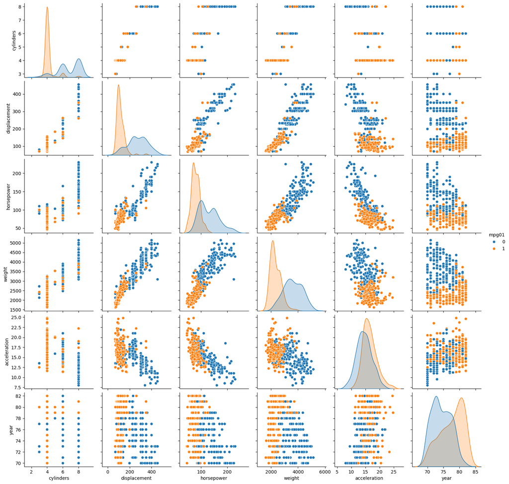

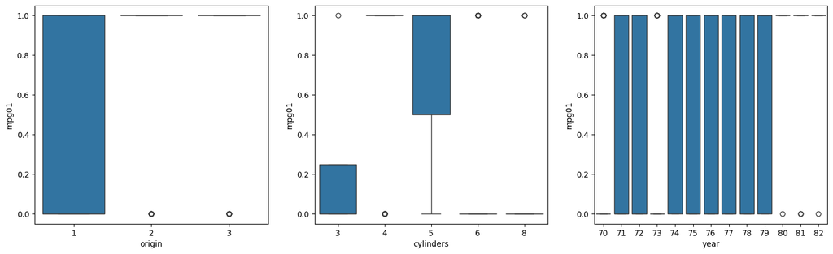

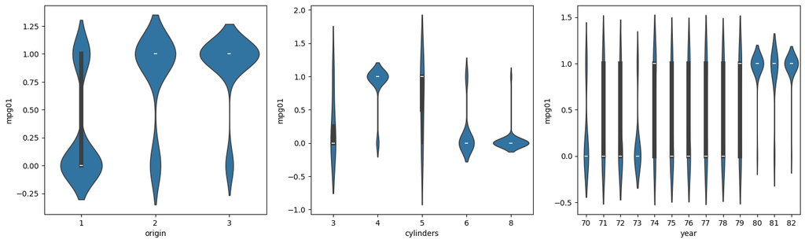

```python
# BEGIN SOLUTION
import matplotlib.pyplot as plt
import seaborn as sns

# Scatterplots for continuous variables
sns.pairplot(df, hue='mpg01', vars=['cylinders', 'displacement', 'horsepower', 'weight', 'acceleration', 'year'])
plt.show()

# Boxplots for categorical variables
plt.figure(figsize=(18, 5))
plt.subplot(1, 3, 1)
sns.boxplot(x='origin', y='mpg01', data=df)
plt.subplot(1, 3, 2)
sns.boxplot(x='cylinders', y='mpg01', data=df)
plt.subplot(1, 3, 3)
sns.boxplot(x='year', y='mpg01', data=df)
plt.show()

# Violin plots for continuous variables
plt.figure(figsize=(18, 5))
plt.subplot(1, 3, 1)
sns.violinplot(x='origin', y='mpg01', data=df)
plt.subplot(1, 3, 2)
sns.violinplot(x='cylinders', y='mpg01', data=df)
plt.subplot(1, 3, 3)
sns.violinplot(x='year', y='mpg01', data=df)
plt.show()


# END SOLUTION
```

Based on these findings, 'cylinders' and 'origin' seem to be the most useful features in predicting `mpg01`, as they exhibit clear differences in the distribution of `mpg01` across their categories. Additionally, certain pairs of continuous variables such as 'displacement', 'horsepower', and 'weight' show potential for predicting `mpg01` based on their scatterplot patterns.

#### C) Split the data into a training set and a test set (70%, 30%). Use `random.seed(4)` to make the training data reproducible.

Link to linear model: https://scikit-learn.org/stable/modules/generated/sklearn.model_selection.train_test_split.html

```python
# BEGIN SOLUTION

from sklearn.model_selection import train_test_split
import numpy as np

# Set random seed for reproducibility
np.random.seed(4)

# Split the data into training and test sets
X_train, X_test, y_train, y_test = train_test_split(df.drop(columns=['mpg01', 'name']), df['mpg01'], test_size=0.3)

# Display the shape of the training and test sets
print("Shape of training set (X):", X_train.shape)
print("Shape of test set (X):", X_test.shape)
print("Shape of training set (y):", y_train.shape)
print("Shape of test set (y):", y_test.shape)

# END SOLUTION
```

```
Shape of training set (X): (274, 8)
Shape of test set (X): (118, 8)
Shape of training set (y): (274,)
Shape of test set (y): (118,)
```

#### d) Perform LDA on the training data in order to predict `mpg01` using the variables that seemed most associated with `mpg01` in (b). What is the test error of the model obtained?

```python
# BEGIN SOLUTION
from sklearn.discriminant_analysis import LinearDiscriminantAnalysis
from sklearn.metrics import accuracy_score

features = ['cylinders', 'displacement', 'horsepower', 'weight', 'acceleration', 'year', 'origin']
```

```python
# BEGIN SOLUTION
lda_model = LinearDiscriminantAnalysis()
lda_model.fit(X_train[features], y_train)

# END SOLUTION
```

```
LinearDiscriminantAnalysis()
```

```python
# BEGIN SOLUTION
y_pred = lda_model.predict(X_test[features])

# END SOLUTION
```

```python
# BEGIN SOLUTION
test_error = 1 - accuracy_score(y_test, y_pred)

# END SOLUTION
# END SOLUTION
```

```python
# BEGIN SOLUTION
print("Test Error:", test_error)
# END SOLUTION
```

```
Test Error: 0.09322033898305082
```

#### e) Perform QDA on the training data in order to predict `mpg01` using the variables that seemed most associated with `mpg01` in (b). What is the test error of the model obtained?

```python
# BEGIN SOLUTION
from sklearn.discriminant_analysis import QuadraticDiscriminantAnalysis
from sklearn.metrics import accuracy_score

# Define the features and target variables for training and test data
features = ['cylinders', 'displacement', 'horsepower', 'weight', 'acceleration', 'year', 'origin']



# END SOLUTION
```

```python
 # BEGIN SOLUTION

# Fit QDA model on the training data
qda_model = QuadraticDiscriminantAnalysis()
qda_model.fit(X_train[features], y_train)



# END SOLUTION
```

```
QuadraticDiscriminantAnalysis()
```

```python
# BEGIN SOLUTION
# Predict mpg01 for the test data
y_pred = qda_model.predict(X_test[features])

# END SOLUTION
```

```python
# BEGIN SOLUTION
# Calculate test error
test_error = 1 - accuracy_score(y_test, y_pred)

print("Test Error:", test_error)
# END SOLUTION
```

```
Test Error: 0.09322033898305082
```

Test Error: 0.09322033898305082

#### f) Perform logistic regression on the training data in order to predict `mpg01` using the variables that seemed most associated with `mpg01` in (b). What is the test error of the model obtained?

Link to linear model: https://scikit-learn.org/stable/modules/generated/sklearn.linear_model.LogisticRegression.html

```python
from sklearn.linear_model import LogisticRegression
from sklearn.metrics import accuracy_score

# Define the features and target variables for training and test data
features = ['cylinders', 'displacement', 'horsepower', 'weight', 'acceleration', 'year', 'origin']
```

```python
# BEGIN SOLUTION
# Fit logistic regression model on the training data with increased max_iter
logreg_model = LogisticRegression(max_iter=1000)
logreg_model.fit(X_train[features], y_train)


# END SOLUTION
```

```
LogisticRegression(max_iter=1000)
```

```python
# BEGIN SOLUTION
# Predict mpg01 for the test data
y_pred = logreg_model.predict(X_test[features])

# Calculate test error
test_error = 1 - accuracy_score(y_test, y_pred)

print("Test Error:", test_error)
# END SOLUTION
```

```
Test Error: 0.07627118644067798
```

Test Error: 0.07627118644067798